# Data Visualization with R

# Introduction

```r
require(tidyverse)
```

## Introduction to the course

In this second part of the course, we’ll walk you through the creation of a Shiny app using a dataset on comics characters. We will start from a basic app and we’ll add complexity step by step. Of course you may think of adding additional features as we go on and as you think of additional data insights!

## Introduction to Shiny

Shiny is a package from RStudio that allows you to easily build interactive web pages with R. You will be able interact and display any R objects: plots, tables, etc. Online resources on Shiny are as rich as you can image. To get a glimpse of the many things you can build with Shiny, out of the many websites with Shiny examples, we suggest you visit https://daattali.com/shiny/ and https://shiny.rstudio.com/gallery/.

If you want to find additional material, you may visit the RStudio official Shiny page https://shiny.rstudio.com/ and we suggest you always keep the [Shiny cheat sheet](http://shiny.rstudio.com/images/shiny-cheatsheet.pdf) on hand when you are developing your Shiny app!

### Required R packages

Before we begin you need to install `Shiny` package:

```r
install.packages("shiny")
```

To ensure you successfully installed Shiny, try running one of the demo apps.

```r
library(shiny)
runExample("01_hello")
```

If the example app is running, press Escape to close the app, and you are ready to build your first Shiny app!

## Comic characters data

The data we will visualise in the Shiny App are the raw data behind the story [Comic Books Are Still Made By Men, For Men And About Men](https://fivethirtyeight.com/features/women-in-comic-books/).

The data come from Marvel Wikia and DC Wikia. Characters were scraped on August 24, appearance counts were scraped on September 2 and the month and year of the first issue each character appeared in was pulled on October 6.

In the data folder of this manual, you find the .R file `comics_data.RData`. Load the dataset as this is the data we’ll work on to build our shiny app:

```r
require(tidyverse)
load("../data/comics_data.RData")
```

Let us quickly explore the dataset so that you can start thinking of intersting data visualisations:

```r
str(comics_data)
```

```
## Classes 'tbl_df', 'tbl' and 'data.frame':    23272 obs. of  14 variables:
##  $ page_id         : int  1678 7139 64786 1868 2460 2458 2166 1833 29481 1837 ...
##  $ name            : chr  "Spider-Man (Peter Parker)" "Captain America (Steven Rogers)" "Wolverine (James \\\"Logan\\\" Howlett)" "Iron Man (Anthony \\\"Tony\\\" Stark)" ...
##  $ urlslug         : chr  "\\/Spider-Man_(Peter_Parker)" "\\/Captain_America_(Steven_Rogers)" "\\/Wolverine_(James_%22Logan%22_Howlett)" "\\/Iron_Man_(Anthony_%22Tony%22_Stark)" ...
##  $ id              : chr  "Secret Identity" "Public Identity" "Public Identity" "Public Identity" ...
##  $ align           : chr  "Good Characters" "Good Characters" "Neutral Characters" "Good Characters" ...
##  $ eye             : chr  "Hazel Eyes" "Blue Eyes" "Blue Eyes" "Blue Eyes" ...
##  $ hair            : chr  "Brown Hair" "White Hair" "Black Hair" "Black Hair" ...
##  $ sex             : chr  "Male Characters" "Male Characters" "Male Characters" "Male Characters" ...
##  $ gsm             : chr  NA NA NA NA ...
##  $ alive           : chr  "Living Characters" "Living Characters" "Living Characters" "Living Characters" ...
##  $ appearances     : int  4043 3360 3061 2961 2258 2255 2072 2017 1955 1934 ...
##  $ first_appearance: chr  "Aug-62" "Mar-41" "Oct-74" "Mar-63" ...
##  $ year            : int  1962 1941 1974 1963 1950 1961 1961 1962 1963 1961 ...
##  $ publisher       : chr  "Marvel" "Marvel" "Marvel" "Marvel" ...
```

The data comes from Marvel Wikia and DC Wikia. The file contains the following variables:

- `page_id`: The unique identifier for that characters page within the wikia
- `name`: The name of the character
- `urlslug`: The unique url within the wikia that takes you to the character
- `id`: The identity status of the character (Secret Identity, Public identity, [on marvel only: No Dual Identity])
- `align`: If the character is Good, Bad or Neutral
- `eye`: Eye color of the character
- `hair`: Hair color of the character
- `sex`: Sex of the character (e.g. Male, Female, etc.)
- `gsm`: If the character is a gender or sexual minority (e.g. Homosexual characters, bisexual characters)
- `alive`: If the character is alive or deceased
- `appearances`: The number of appareances of the character in comic books (as of Sep. 2, 2014. Number will become increasingly out of date as time goes on.)
- `first_appearances` The month and year of the character’s first appearance in a comic book, if available
- `year`: The year of the character’s first appearance in a comic book, if available
- `publisher`: weather the character was publishded by Marvel or DC

And we can start plotting the data so that we get some insights. For example, we may plot the number of new female and male characters each year:

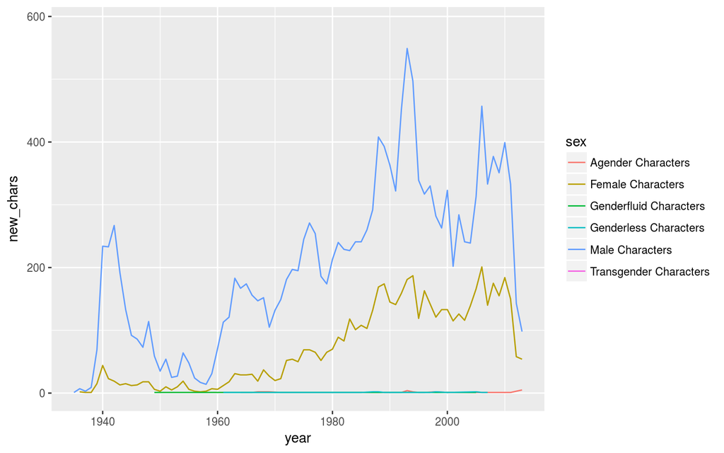

```r
pp <- ggplot(comics_data %>%
         filter(!is.na(sex)) %>%
         group_by(year, sex) %>%
         summarise(new_chars = n()), aes(x=year, y=new_chars, sex)) +
  geom_line(aes(colour = sex))
pp
```

and see whether they change according to the different publishers:

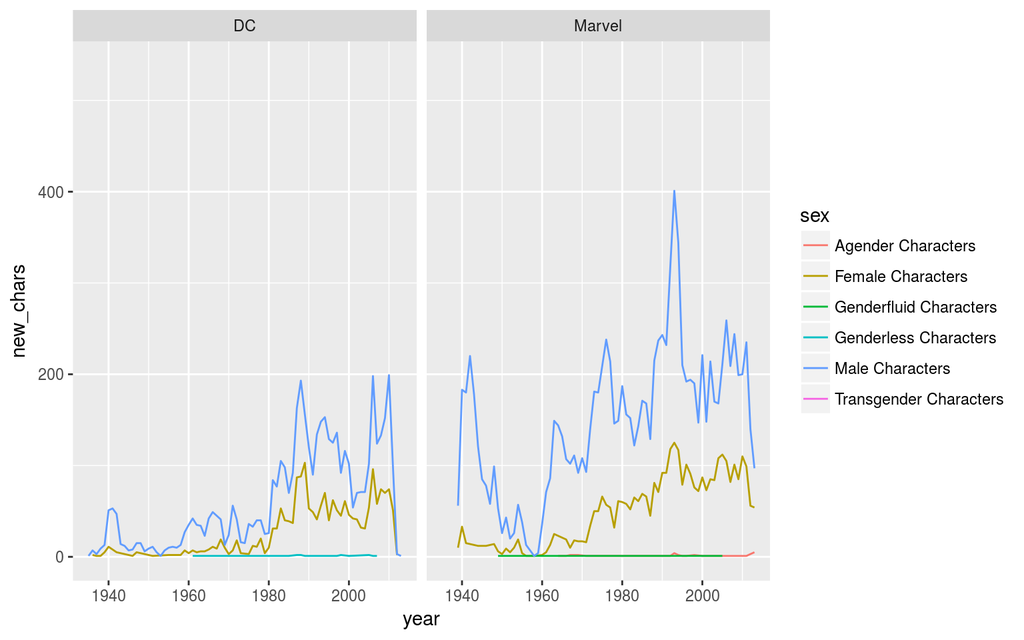

```r
pp2 <- ggplot(comics_data %>%
         filter(!is.na(sex)) %>%
         group_by(year, sex, publisher) %>%
         summarise(new_chars = n()), aes(x=year, y=new_chars, sex)) +
  geom_line(aes(colour = sex)) + facet_grid( ~ publisher)
pp2
```